# Analysis of the Global Transition from Fossil Fuels to Renewable and Nuclear Energy from 1990-2014

By Angela Liu

### Introduction

Today, we are constantly reminded of the importance of reducing our reliance on fossil fuels and take up renewable energy to combat global warming. To summarize, renewable energy is energy collected from resources naturally replenished within a human lifetime. Common examples include wind, solar, and geothermal. Fossil fuels are a nonrenewable energy source that are used far more quickly than they are being replenished and burning them release greenhouse gasses that warm up the planet.

Despite hearing about frequent breakthroughs in renewable technology, I wonder how much progress have we actually made and when we can start relying on cleaner energy sources. It is only natural to ask when will we stop stop relying fossil fuels as our primary source for energy? With this online tutorial, I hope to enlighten readers with the truth about energy production.

We will be focusing on 8 major energy sources:

- solar: solar panels collect sunlight to generate electricity or sunlight is used to heat up water to move turbines
- wind: targe turbines use wind to turn and generate electricty
- geothermal: hot rocks deep inside the earth heat up water to produce steam that moves turbines
- hydropower: moving water turns generators in dams
- wave/tidal: the kinetic energy of waves and tides is used to produce electricty
- biomass: organic materials is used for heat and industrial fuel
- fossil: hydrocarbons(most notably coal, oil, and natural gas) are used as fuel and heating
- nuclear: nuclear fission creates heat to produce electricity

### Gathering Data

The data I used come from a large csv file collect by the United Nations from Kaggle: https://www.kaggle.com/unitednations/international-energy-statistics along with an Energy Questionare Guideline to help explain the data.

All the other links I will be extracting supporting data from:

https://www.eia.gov/international/rankings/world?pa=12&u=0&f=A&v=none&y=01%2F01%2F2018 for top energy producing countries in 2014

https://www.euronuclear.org/glossary/fuel-comparison/ for metric tons of uranium to kwh conversion

https://extension.psu.edu/calculating-the-green-weight-of-wood-species for volume of wood to metric tons conversion

https://b8f65cb373b1b7b15feb-c70d8ead6ced550b4d987d7c03fcdd1d.ssl.cf3.rackcdn.com/cms/guidance_docs/pdfs/000/000/477/original/CDP-Conversion-of-fuel-data-to-MWh.pdf?1479755175 for other energy conversions

```python
import numpy as np
import pandas as pd
import matplotlib.pyplot as plt
import matplotlib as mpl
import seaborn as sns
import sklearn
```

```python
df = pd.read_csv('all_energy_statistics.csv')
df.rename(columns = {'country_or_area':'country','commodity_transaction':'commodity',
                      'year':'year','unit':'unit','quantity':'quantity',
                    'quantity_footnotes':'footnotes','category':'category'}, inplace=True)
df.head()
```

|  | country | commodity | year | unit | quantity | footnotes | category |
| --- | --- | --- | --- | --- | --- | --- | --- |
| 0 | Austria | Additives and Oxygenates - Exports | 1996 | Metric tons, thousand | 5.0 | NaN | additives_and_oxygenates |
| 1 | Austria | Additives and Oxygenates - Exports | 1995 | Metric tons, thousand | 17.0 | NaN | additives_and_oxygenates |
| 2 | Belgium | Additives and Oxygenates - Exports | 2014 | Metric tons, thousand | 0.0 | NaN | additives_and_oxygenates |
| 3 | Belgium | Additives and Oxygenates - Exports | 2013 | Metric tons, thousand | 0.0 | NaN | additives_and_oxygenates |
| 4 | Belgium | Additives and Oxygenates - Exports | 2012 | Metric tons, thousand | 35.0 | NaN | additives_and_oxygenates |

```python
len(df)
```

```
1189482
```

### Tidying and Cleaning Data

That is far too many data and most of them are irrelavent to my topic. Stating with what's easy, I dropped a column I didn't need.

```python
df.drop(columns=['footnotes'], inplace = True)
df.head()
```

|  | country | commodity | year | unit | quantity | category |
| --- | --- | --- | --- | --- | --- | --- |
| 0 | Austria | Additives and Oxygenates - Exports | 1996 | Metric tons, thousand | 5.0 | additives_and_oxygenates |
| 1 | Austria | Additives and Oxygenates - Exports | 1995 | Metric tons, thousand | 17.0 | additives_and_oxygenates |
| 2 | Belgium | Additives and Oxygenates - Exports | 2014 | Metric tons, thousand | 0.0 | additives_and_oxygenates |
| 3 | Belgium | Additives and Oxygenates - Exports | 2013 | Metric tons, thousand | 0.0 | additives_and_oxygenates |
| 4 | Belgium | Additives and Oxygenates - Exports | 2012 | Metric tons, thousand | 35.0 | additives_and_oxygenates |

```python
c = df.category.unique()
c
```

```
array(['additives_and_oxygenates', 'animal_waste', 'anthracite',
       'aviation_gasoline', 'bagasse', 'biodiesel', 'biogases',
       'biogasoline', 'bitumen', 'black_liquor', 'blast_furnace_gas',
       'brown_coal_briquettes', 'brown_coal', 'charcoal', 'coal_tar',
       'coke_oven_coke', 'coking_coal', 'conventional_crude_oil',
       'direct_use_of_geothermal_heat',
       'direct_use_of_solar_thermal_heat',
       'electricity_net_installed_capacity_of_electric_power_plants',
       'ethane', 'falling_water', 'fuel_oil', 'fuelwood', 'gas_coke',
       'gas_oil_diesel_oil', 'gasoline_type_jet_fuel', 'gasworks_gas',
       'geothermal', 'hard_coal', 'heat', 'hydro', 'industrial_waste',
       'kerosene_type_jet_fuel', 'lignite', 'liquified_petroleum_gas',
       'lubricants', 'motor_gasoline', 'municipal_wastes', 'naphtha',
       'natural_gas_including_lng', 'natural_gas_liquids',
       'nuclear_electricity', 'of_which_biodiesel',
       'of_which_biogasoline', 'oil_shale_oil_sands',
       'other_bituminous_coal', 'other_coal_products',
       'other_hydrocarbons', 'other_kerosene', 'other_liquid_biofuels',
       'other_oil_products_n_e_c', 'other_recovered_gases',
       'other_vegetal_material_and_residues', 'paraffin_waxes',
       'patent_fuel', 'peat', 'peat_products', 'petroleum_coke',
       'refinery_feedstocks', 'refinery_gas', 'solar_electricity',
       'sub_bituminous_coal', 'thermal_electricity',
       'tide_wave_and_ocean_electricity', 'total_electricity',
       'total_refinery_output', 'uranium',
       'white_spirit_and_special_boiling_point_industrial_spirits',
       'wind_electricity'], dtype=object)
```

Even in unique categories, there is too much data here. Let's first isolate the important bits by only focusing on the top 30 energy producing countries in 2014, since that is the last date that is recorded here.

The website we will use to find the top countries is [here](https://www.eia.gov/international/rankings/world?pa=12&u=0&f=A&v=none&y=01%2F01%2F2018).

Unfortunately, this is a dynamic webpage so extracting the html doesn't work. Therefore we need to manually enter the information ourselves into a csv format. An easy way to do this is to highlight everything from column Ranking all the way to the row with rank 30 and paste that into excel. Make sure that the scrollbar is set to 2014. Then we save it as an csv utf-8 file and upload it into our notebook.

```python
top = pd.read_csv('top_countries.csv')
top.rename(columns = {'Rank':'rank','Country':'country',
                      'quadrillion Btu':'production'}, inplace=True)
top.drop(columns=['Unnamed: 3'], inplace = True)
```

```python
top
```

|  | Ranking | country | production |
| --- | --- | --- | --- |
| 0 | 1 | China | 114.791 |
| 1 | 2 | United States | 87.720 |
| 2 | 3 | Russia | 56.856 |
| 3 | 4 | Saudi Arabia | 27.517 |
| 4 | 5 | Canada | 20.782 |
| 5 | 6 | Australia | 14.987 |
| 6 | 7 | India | 14.682 |
| 7 | 8 | Indonesia | 14.126 |
| 8 | 9 | Iran | 13.901 |
| 9 | 10 | Brazil | 10.809 |
| 10 | 11 | Qatar | 10.007 |
| 11 | 12 | United Arab Emirates | 9.230 |
| 12 | 13 | Norway | 9.126 |
| 13 | 14 | Mexico | 8.381 |
| 14 | 15 | Kazakhstan | 7.555 |
| 15 | 16 | Venezuela | 7.348 |
| 16 | 17 | Iraq | 7.235 |
| 17 | 18 | Nigeria | 6.790 |
| 18 | 19 | Algeria | 6.562 |
| 19 | 20 | Kuwait | 6.498 |
| 20 | 21 | South Africa | 5.958 |
| 21 | 22 | France | 5.398 |
| 22 | 23 | Colombia | 5.353 |
| 23 | 24 | Germany | 4.926 |
| 24 | 25 | United Kingdom | 4.698 |
| 25 | 26 | Malaysia | 3.958 |
| 26 | 27 | Angola | 3.803 |
| 27 | 28 | Egypt | 3.462 |
| 28 | 29 | Turkmenistan | 3.372 |
| 29 | 30 | Oman | 3.140 |

```python
df2 = df.loc[df['country'].isin(top['country'])]
```

```python
# display all contents inside dataframe
pd.set_option('display.max_colwidth', None)
```

```python
df2.head()
```

|  | country | commodity | year | unit | quantity | category |
| --- | --- | --- | --- | --- | --- | --- |
| 26 | France | Additives and Oxygenates - Exports | 2014 | Metric tons, thousand | 119.0 | additives_and_oxygenates |
| 27 | France | Additives and Oxygenates - Exports | 2013 | Metric tons, thousand | 102.0 | additives_and_oxygenates |
| 28 | France | Additives and Oxygenates - Exports | 2012 | Metric tons, thousand | 62.0 | additives_and_oxygenates |
| 29 | France | Additives and Oxygenates - Exports | 2011 | Metric tons, thousand | 55.0 | additives_and_oxygenates |
| 30 | France | Additives and Oxygenates - Exports | 2010 | Metric tons, thousand | 87.0 | additives_and_oxygenates |

```python
print(len(df))
print(len(df2))
```

```
1189482
242587
```

Now we need to focus on production, so we only care about output, not about consumption.

```python
df3 = df2.loc[(df2['commodity'].str.find('consumption') == -1) & (df2['commodity'].str.find('Consumption') == -1)]
```

```python
len(df3)
```

```
145683
```

```python
df4 = df3.loc[(df3['commodity'].str.find('produc') != -1) | (df3['commodity'].str.find('Produc') != -1)]
```

```python
len(df4)
```

```
48493
```

```python
# check for missing data
df4.isnull().values.any()
```

```
False
```

Good news! We have no missing data to account for.

```python
# pads list with None until given length n
def pad(list, n):
    for i in range(n-len(list)):
        list.append(None)
```

```python
df4.category.unique()
```

```
array(['additives_and_oxygenates', 'animal_waste', 'anthracite',
       'aviation_gasoline', 'bagasse', 'biodiesel', 'biogases',
       'biogasoline', 'bitumen', 'black_liquor', 'blast_furnace_gas',
       'brown_coal_briquettes', 'brown_coal', 'charcoal', 'coal_tar',
       'coke_oven_coke', 'coking_coal', 'conventional_crude_oil',
       'electricity_net_installed_capacity_of_electric_power_plants',
       'ethane', 'fuel_oil', 'fuelwood', 'gas_coke', 'gas_oil_diesel_oil',
       'gasoline_type_jet_fuel', 'gasworks_gas', 'geothermal',
       'hard_coal', 'heat', 'hydro', 'industrial_waste',
       'kerosene_type_jet_fuel', 'lignite', 'liquified_petroleum_gas',
       'lubricants', 'motor_gasoline', 'municipal_wastes', 'naphtha',
       'natural_gas_including_lng', 'natural_gas_liquids',
       'nuclear_electricity', 'of_which_biodiesel',
       'other_bituminous_coal', 'other_hydrocarbons', 'other_kerosene',
       'other_liquid_biofuels', 'other_oil_products_n_e_c',
       'other_recovered_gases', 'other_vegetal_material_and_residues',
       'paraffin_waxes', 'patent_fuel', 'peat', 'petroleum_coke',
       'refinery_feedstocks', 'refinery_gas', 'solar_electricity',
       'sub_bituminous_coal', 'thermal_electricity',
       'tide_wave_and_ocean_electricity', 'total_electricity', 'uranium',
       'white_spirit_and_special_boiling_point_industrial_spirits',
       'wind_electricity'], dtype=object)
```

There are too many categories and we only want 7 of them: bio, geo, hydro, nuclear, solar, wave, and wind. However, according to the Energy Questionare Guidelines, most of these categories are variants of fossil fuels and biofuels. To group all these different categories together, I created a new Dataframe 'order', that lists keywords to determine which group each category belong to. I left 'electricity_net_installed_capacity_of_electric_power_plants', 'heat', and 'total_electricity' out because I decided these groups are too broad to be meaningful.

```python
# list include all non-fossil fuel sources
# fossil fuel will encompass basically everything else so it's not listed
bio = ['fuelwood','charcoal','bagasse','animal_waste','municipal_wastes','industrial_waste','black_liquor','of_which_biodiesel','biodiesel', 'biogases','biogasoline','vegetal']
geo = ['geothermal']
hydro = ['hydro']
nuclear = ['nuclear_electricity','uranium']
solar = ['solar_electricity','thermal_electricity']
wave = ['tide_wave_and_ocean_electricity']
wind = ['wind_electricity']

pad(bio,len(bio))
pad(geo,len(bio))
pad(hydro,len(bio))
pad(nuclear,len(bio))
pad(solar,len(bio))
pad(wave,len(bio))
pad(wind,len(bio))
order = pd.DataFrame({'bio':bio,
                      'geo':geo,
                      'hydro':hydro,
                      'nuclear':nuclear,
                      'solar':solar,
                      'wave':wave,
                      'wind':wind})
order
```

|  | bio | geo | hydro | nuclear | solar | wave | wind |
| --- | --- | --- | --- | --- | --- | --- | --- |
| 0 | fuelwood | geothermal | hydro | nuclear_electricity | solar_electricity | tide_wave_and_ocean_electricity | wind_electricity |
| 1 | charcoal | None | None | uranium | thermal_electricity | None | None |
| 2 | bagasse | None | None | None | None | None | None |
| 3 | animal_waste | None | None | None | None | None | None |
| 4 | municipal_wastes | None | None | None | None | None | None |
| 5 | industrial_waste | None | None | None | None | None | None |
| 6 | black_liquor | None | None | None | None | None | None |
| 7 | of_which_biodiesel | None | None | None | None | None | None |
| 8 | biodiesel | None | None | None | None | None | None |
| 9 | biogases | None | None | None | None | None | None |
| 10 | biogasoline | None | None | None | None | None | None |
| 11 | vegetal | None | None | None | None | None | None |

```python
delete = []
for index, row in df4.iterrows():
    if row['category'] == 'electricity_net_installed_capacity_of_electric_power_plants' or row['category'] == 'heat' or row['category'] == 'total_electricity':
        delete.append(index)
```

```python
df4.drop(index=delete, axis=0, inplace=True)
```

```python
countries = df4.country.unique()
countries
```

```
array(['Colombia', 'France', 'Germany', 'Mexico', 'Norway',
       'United Kingdom', 'United States', 'Australia', 'Canada',
       'South Africa', 'Algeria', 'Brazil', 'China', 'Egypt', 'Indonesia',
       'Iraq', 'Kazakhstan', 'India', 'Malaysia', 'Nigeria', 'Angola',
       'Kuwait', 'Saudi Arabia', 'Oman', 'Qatar', 'Turkmenistan',
       'United Arab Emirates'], dtype=object)
```

```python
# returns the energy source name of a category for given row index
def get_source(i):
    cat = df4['category'].iloc[i]
    sources = list(order.columns.values)
    if cat in sources:
        return cat
    for s in sources:
        if cat in list(order[s]):
            return s
    return 'fossil'
```

Now I will create a brand new dataframe that will only hold country, year, unit, quantity, source, and category. That way, it will be much easier to gather all data for a single type of energy source.

```python
# takes a few minutes
df5 = pd.DataFrame(columns=['country','year','unit','quantity','source','category'])
for i in range(len(df4)):
    dict={'country':df4['country'].iloc[i],'year':df4['year'].iloc[i],'unit':df4['unit'].iloc[i],'quantity':df4['quantity'].iloc[i],'source':get_source(i),'category':df4['category'].iloc[i]}
    df5 = df5.append(dict, ignore_index=True)
```

```python
df5.head()
```

|  | country | year | unit | quantity | source | category |
| --- | --- | --- | --- | --- | --- | --- |
| 0 | Colombia | 2014 | Metric tons, thousand | 34.53 | fossil | additives_and_oxygenates |
| 1 | Colombia | 2013 | Metric tons, thousand | 34.53 | fossil | additives_and_oxygenates |
| 2 | Colombia | 2012 | Metric tons, thousand | 38.22 | fossil | additives_and_oxygenates |
| 3 | Colombia | 2011 | Metric tons, thousand | 36.39 | fossil | additives_and_oxygenates |
| 4 | Colombia | 2010 | Metric tons, thousand | 30.21 | fossil | additives_and_oxygenates |

Our data is in a much simpler form and read to be analyzed. Here are what the columns represent:

- country: country where energy is produced
- year: year of recorded production
- unit: unit of measurement of the given quantity
- quantity: how much of the energy is produced in given unit
- source: one of the 8 groups of energy: bio, geo, hydro, nuclear, solar, wave, wind, and fossil
- category: category of original energy data that gives more specific information about that energy

### Exploratory Data Analysis

Now that we have our data in a nicer form, lets start by looking at energy production trends from 1990-2014 by the top 30 countries. To plot each energy source properly, we first need to make sure that all the data in each source have the same units.

```python
for i in df5.source.unique():
    data = df5.loc[(df5['source'].str.match(i))]
    print(i)
    print(data.unit.unique())
```

```
fossil
['Metric tons,  thousand' 'Terajoules']
bio
['Terajoules' 'Metric tons,  thousand' 'Cubic metres, thousand']
geo
['Kilowatt-hours, million']
hydro
['Kilowatt-hours, million']
nuclear
['Kilowatt-hours, million' 'Metric Tons']
solar
['Kilowatt-hours, million']
wave
['Kilowatt-hours, million']
wind
['Kilowatt-hours, million']
```

```python
df5.loc[((df5['source'].str.match('nuclear'))) & (df5['unit'].str.match('Metric Tons'))].category.unique()
```

```
array(['uranium'], dtype=object)
```

Fixing nuclear is relatively easy as the only category that uses metric ton is uranium. All we need is the converting factor for uranium. This [website](https://www.euronuclear.org/glossary/fuel-comparison/) gives an approximate 45,000 kWh per 1 kg of uranium.

1 kg = 45000 kwh

1 metric ton = 45,000,000 kwh = 45 gwh

```python
# for each row with source as nuclear and unit as Metric Tons, apply conversion and record unit as kwh, mil
for i in df5.loc[((df5['source'].str.match('nuclear'))) & (df5['unit'].str.match('Metric Tons'))].index:
    df5.at[i,'quantity'] *= 45
    df5.at[i,'unit'] = 'Kilowatt-hours, million'
```

```python
df5.loc[((df5['source'].str.match('bio'))) & (df5['unit'].str.match('Terajoules'))].category.unique()
```

```
array(['animal_waste', 'biogases', 'black_liquor', 'industrial_waste',
       'municipal_wastes'], dtype=object)
```

```python
df5.loc[((df5['source'].str.match('bio'))) & (df5['unit'].str.match('Metric tons,  thousand'))].category.unique()
```

```
array(['bagasse', 'biodiesel', 'biogasoline', 'charcoal',
       'of_which_biodiesel'], dtype=object)
```

```python
df5.loc[((df5['source'].str.match('bio'))) & (df5['unit'].str.match('Cubic metres, thousand'))].category.unique()
```

```
array(['fuelwood'], dtype=object)
```

Fixing bio somewhat harder as there are now 3 different units, each with several different categories. First we need to convert cubic meters, thousand into metric tons, thousand for fuelwood. This [website](https://extension.psu.edu/calculating-the-green-weight-of-wood-species) gives an approximate conversion of 1500 kg/m3.

1 m^3 = 1500 kg = 1.5 metric ton

1.5 m^3 = 2.25 metric ton

1.5 m^3 = 2.25e-3 thousand metric tons

```python
# for each row with source as bio and unit as cubic meters, thousand, apply conversion and record unit as metric tons, thousand
for i in df5.loc[((df5['source'].str.match('bio'))) & (df5['unit'].str.match('Cubic metres, thousand'))].index:
    df5.at[i,'quantity'] *= 2.25e-3
    df5.at[i,'unit'] = 'Metric tons,  thousand'
```

Then we convert all bio in metric tons, thousands to terajoules using conversion found in [pdf](https://b8f65cb373b1b7b15feb-c70d8ead6ced550b4d987d7c03fcdd1d.ssl.cf3.rackcdn.com/cms/guidance_docs/pdfs/000/000/477/original/CDP-Conversion-of-fuel-data-to-MWh.pdf?1479755175)

1 metric ton = .001 Gg 1 metric ton, thousand = 1 Gg (just need to multiply by TJ/Gg)

Charcoal: (31.05 + 29.5)/2 = 30.275 TJ/Gg

Biogasoline: (28.42 + 27)/2 = 27.71 TJ/Gg

Biodiesels: (28.42 + 27)/2 = 27.71 TJ/Gg

Of_which_biodiesel = 27.71 TJ/Gg

Wood/Wood waste: (16.42 + 15.6)/2 = 16.01 TJ/Gg

Bagasse (and anything else not accounted for): not listed so we take avg of above listed = 25.88 TJ/Gg

```python
for i in df5.loc[((df5['source'].str.match('bio'))) & (df5['unit'].str.match('Metric tons,  thousand'))].index:
    if df5['category'].iloc[i] == 'fuelwood':
        df5.at[i,'quantity'] *= 16.01
    elif df5['category'].iloc[i] == 'biodiesel':
        df5.at[i,'quantity'] *= 27.71
    elif df5['category'].iloc[i] == 'biogasoline':
        df5.at[i,'quantity'] *= 27.71
    elif df5['category'].iloc[i] == 'charcoal':
        df5.at[i,'quantity'] *= 30.275
    else:
        df5.at[i,'quantity'] *= 25.88
    # units are replaced with TJ
    df5.at[i,'unit'] = 'Terajoules'
```

```python
df5.loc[((df5['source'].str.match('fossil'))) & (df5['unit'].str.match('Metric tons,  thousand'))].category.unique()
```

```
array(['additives_and_oxygenates', 'anthracite', 'aviation_gasoline',
       'bitumen', 'brown_coal_briquettes', 'brown_coal', 'coal_tar',
       'coking_coal', 'conventional_crude_oil', 'ethane', 'fuel_oil',
       'gas_coke', 'gas_oil_diesel_oil', 'gasoline_type_jet_fuel',
       'hard_coal', 'kerosene_type_jet_fuel', 'lignite',
       'liquified_petroleum_gas', 'lubricants', 'motor_gasoline',
       'naphtha', 'natural_gas_liquids', 'other_bituminous_coal',
       'other_hydrocarbons', 'other_kerosene', 'other_liquid_biofuels',
       'other_oil_products_n_e_c', 'paraffin_waxes', 'patent_fuel',
       'peat', 'petroleum_coke', 'refinery_feedstocks', 'refinery_gas',
       'sub_bituminous_coal',
       'white_spirit_and_special_boiling_point_industrial_spirits'],
      dtype=object)
```

```python
df5.loc[((df5['source'].str.match('fossil'))) & (df5['unit'].str.match('Terajoules'))].category.unique()
```

```
array(['blast_furnace_gas', 'coke_oven_coke', 'gasworks_gas',
       'natural_gas_including_lng', 'other_recovered_gases',
       'other_vegetal_material_and_residues'], dtype=object)
```

```python
import re
# string of copy-pasted table
raw="""
Crude oil 44.53 42.3
Orimulsion 28.95 27.5
Natural Gas Liquids 46.53 44.2
Motor Gasoline 46.63 44.3
Aviation Gasoline 46.63 44.3
Jet Gasoline 46.63 44.3
Jet Kerosene 46.42 44.1
Other Kerosene 46.11 43.8
Shale oil 40.11 38.1
Gas/Diesel oil 45.26 43
Residual Fuel oil 42.53 40.4
Liquefied Petroleum Gases 49.79 47.3
Ethane 48.84 46.4
Naphtha 46.84 44.5
Bitumen 42.32 40.2
Lubricants 42.32 40.2
Petroleum coke 34.21 32.5
Refinery feedstocks 45.26 43
Refinery Gas 55.00 49.5
Paraffin waxes 42.32 40.2
White Spirit & SBP 42.32 40.2
Other petroleum products 42.32 40.2
Coal &
derived
substances
Anthracite 28.11 26.7
Coking coal 29.68 28.2
Other bituminous coal 27.16 25.8
Sub-bituminous coal 19.89 18.9
Lignite 12.53 11.9
Oil shale and tar sands 9.37 8.9
Brown coal briquettes 21.79 20.7
Patent fuel 21.79 20.7
Coke oven coke & lignite coke 29.68 28.2
Gas coke 29.68 28.2
Coal tar 29.47 28
Gas works gas 43.00 38.7
Coke oven gas 43.00 38.7
Blast furnace gas 2.74 2.47
Gaseous (kg/m3
)
a,b Liquid (kg/L)b Gaseous (lb/ft3
)
a,b Liquid (lb/gal)b
Range Typical Range Typical Range Typical Range Typical
Coal-based fuels
Anthracite coal
Oxygen steel furnace gas 7.84 7.06
Natural gas Natural Gas 53.33 48
Nonbiomass
waste fuels
Municipal wastes (non-biomass fraction) 10.53 10
Industrial wastes NA NA
Waste oils 42.32 40.2
Peat Peat* 10.27 9.76
Biomass
fuels
Wood/Wood waste 16.42 15.6
Sulphite lyes (Black liquor) 12.42 11.8
Other primary solid biomass fuels 12.21 11.6
Charcoal 31.05 29.5
Biogasoline 28.42 27
Biodiesels 28.42 27
Other liquid biofuels 28.84 27.4
Landfill gas** 56.00 50.4
Sludge gas** 56.00 50.4
Other biogas 56.00 50.4
Municipal wastes (biomass fraction) 12.21 11.6"""

# split string by spaces and newlines
list1=re.split(" |\n",raw)
# first element is an empty string so get rid of it
list1=list1[1:]
list2=[]
# for each element, add to list2 if converting to float does not cause error
for l in list1:
    try:
        ele=float(l)
        list2.append(ele)
    except ValueError:
        pass

# print out avg of all float values
avg = sum(list2)/len(list2)
print(avg)
```

```
33.2339423076923
```

1 metric ton = .001 Gg

1000 metric ton = 1 Gg

```python
for i in df5.loc[((df5['source'].str.match('fossil'))) & (df5['unit'].str.match('Metric tons,  thousand'))].index:
    df5.at[i,'quantity'] *= avg
    df5.at[i,'unit'] = 'Terajoules'
```

Now that all of bio and fossil are in terajoules, we can easily convert to gwh, or a million kwh.

1 TJ = .2778 gwh

```python
for i in df5.loc[(df5['unit'].str.match('Terajoules'))].index:
    df5.at[i,'quantity'] *= .2778
    df5.at[i,'unit'] = 'Kilowatt-hours, million'
```

All units are finally in Kilowatt-hours, million so we can finally start plotting trends for each energy source.

```python
# returns tuple containing year, total quantity, and country for given country, year, and source
def get_quantity(country,year,source):
    total = -1
    data = df5.loc[(df5['country'] == country) & (df5['year'] == year) & (df5['source'] == source)]
    if len(data) > 0:
        if total == -1:
            total = 0
        for d in data.index:
            total += df5.loc[d, 'quantity']

    return year, total, country
```

```python
# default color cycle is too small so we make our own
mpl.rcParams['axes.prop_cycle'] = mpl.cycler(color=['#1f77b4', '#ff7f0e', '#2ca02c', '#d62728',
                                                    '#9467bd', '#8c564b', '#e377c2', '#7f7f7f',
                                                    '#bcbd22', '#17becf', '#ff7e7e', '#ffdb7e',
                                                    '#cdff7e', '#7effae', '#7effff', '#01009f',
                                                    '#5c009f', '#dddddd', '#ff7ec3', '#ff0000'])
```

```python
# too many countries to put in legend so get top 3 countries of each source
top_prod = {}
sources = np.append(order.columns.values, ['fossil'])

for s in sources:
    sorted = [get_quantity(C, 2014, s) for C in countries]
    sorted = [(s[1],s[2]) for s in sorted]
    sorted.sort(reverse=True)
    sorted = [s[1] for s in sorted]
    top_prod[s]=sorted[:3]
top_prod
```

```
{'bio': ['Brazil', 'United States', 'China'],
 'geo': ['United States', 'Indonesia', 'Mexico'],
 'hydro': ['China', 'Canada', 'Brazil'],
 'nuclear': ['Kazakhstan', 'United States', 'Canada'],
 'solar': ['China', 'United States', 'India'],
 'wave': ['France', 'Canada', 'United Kingdom'],
 'wind': ['United States', 'China', 'Germany'],
 'fossil': ['China', 'United States', 'India']}
```

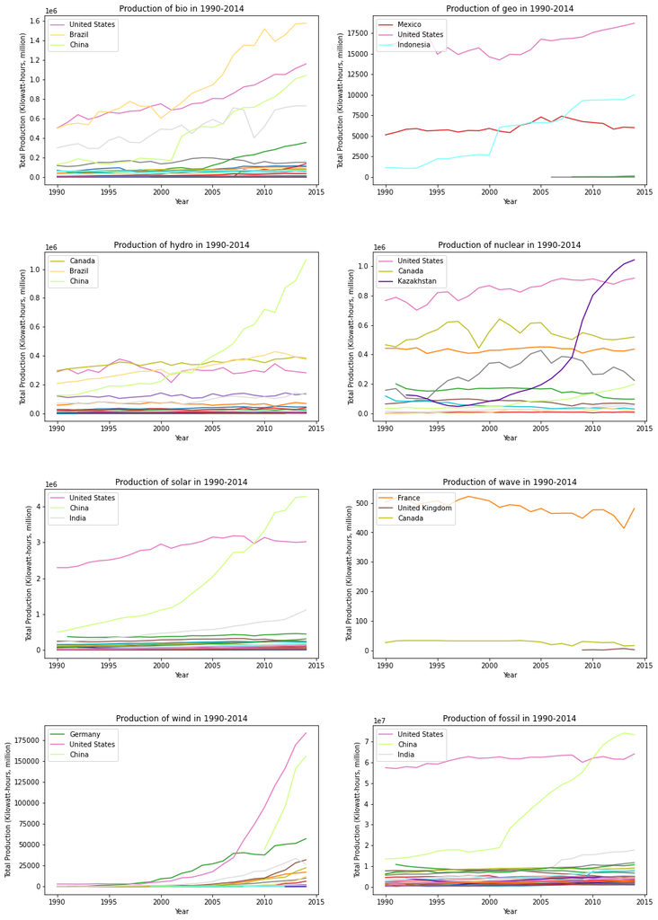

```python
num_rows = 4
num_cols = 2

fig, axes = plt.subplots(nrows=num_rows, ncols=num_cols)

i = 0
for r in range(0,num_rows):
    for c in range (0, num_cols):
        if i < 8:
            focus = sources[i]

            # plot line data for each country
            for C in countries:
                X=[]
                Y=[]
                for y in range(1990, 2015):
                    tup = get_quantity(C, y, focus)
                    # an element is only added to lists if that country listed that commodity that year
                    if int(tup[1]) != -1:
                        X.append(tup[0])
                        Y.append(tup[1])
                # plot for each country
                if C in top_prod[focus]:
                    axes[r,c].plot(X, Y, label = C)
                else:
                    axes[r,c].plot(X, Y, label = None)

            axes[r,c].set_xlabel('Year')
            axes[r,c].set_ylabel('Total Production (Kilowatt-hours, million)')
            axes[r,c].set_title('Production of '+ str(focus) +' in 1990-2014')
            #wind's plot contains the most open space so that's where I show the legend(fix this)
            axes[r,c].legend(loc='upper left')
            i += 1

# adjust size and padding
fig.set_figwidth(num_cols*8)
fig.set_figheight(num_rows*6)

plt.subplots_adjust(wspace=0.2,
                    hspace=0.4)
```

This is not looking so good for renewable energy. If we look on the y-axis, fossil fuel productions are much higher that other sources of energy, more than 10 times in fact, and they still seem to be on an upward trend for most countries. Actually, all energy sources seem to be on an upward trend except for wave energy, which isn't too surprising given the challenges of generating electricity from waves. Other discoveries that match our intuition is how often China and United States show up as top producers of energy in most sources. One intriguing part is the massive growth of nuclear power in Kazakhstan, which is not a country I expected to show up among the top producer. That may warrant further research but for now, I want to focus on the general energy production.

### Checking for Normal Distribution

To plot linear regressions, we must see if the data is normally distributed. Using seaborn, we can use a violin plot to check if energy productions each year follows an approximate normal distribution. Therfore I plotted a violin plot for each energy source with normalized quantities.

```python
# add normalize column
df5['normalized_quantity']=np.where(df5['quantity']==0,0,(df5['quantity']-df5['quantity'].mean())/df5['quantity'].std())
```

```python
df5.head()
```

|  | country | year | unit | quantity | source | category | normalized_quantity |
| --- | --- | --- | --- | --- | --- | --- | --- |
| 0 | Colombia | 2014 | Kilowatt-hours, million | 318.794398 | fossil | additives_and_oxygenates | -0.176255 |
| 1 | Colombia | 2013 | Kilowatt-hours, million | 318.794398 | fossil | additives_and_oxygenates | -0.176255 |
| 2 | Colombia | 2012 | Kilowatt-hours, million | 352.861914 | fossil | additives_and_oxygenates | -0.176209 |
| 3 | Colombia | 2011 | Kilowatt-hours, million | 335.966642 | fossil | additives_and_oxygenates | -0.176232 |
| 4 | Colombia | 2010 | Kilowatt-hours, million | 278.910477 | fossil | additives_and_oxygenates | -0.176309 |

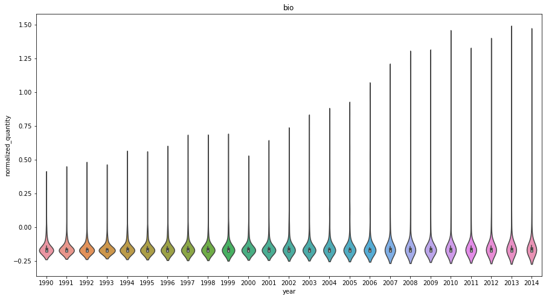

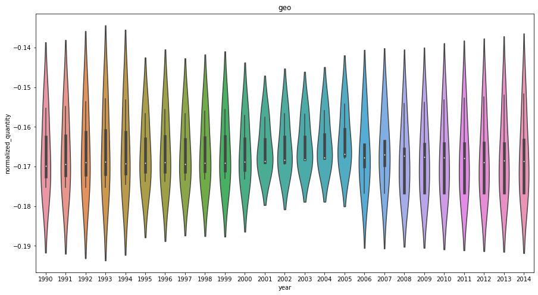

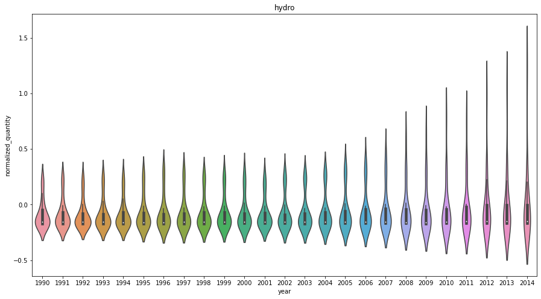

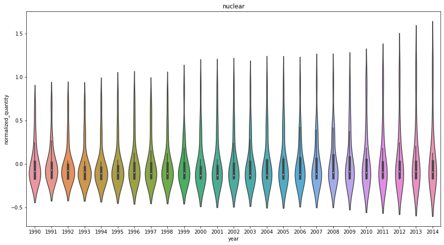

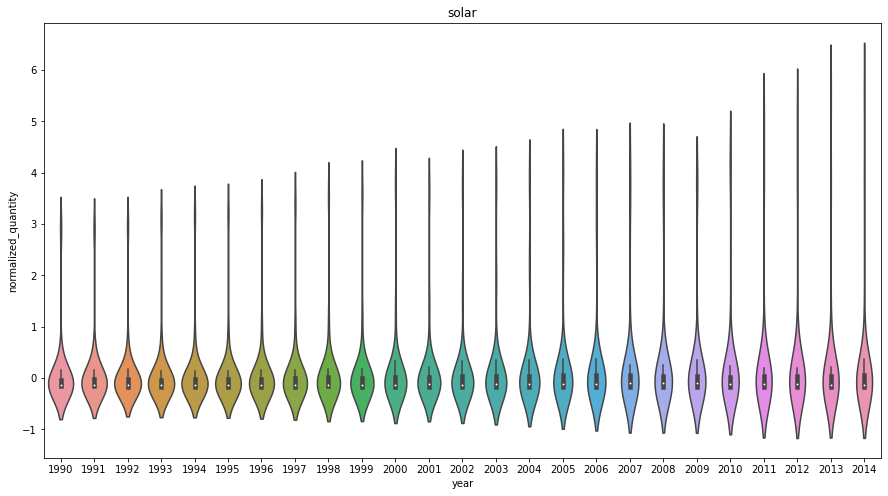

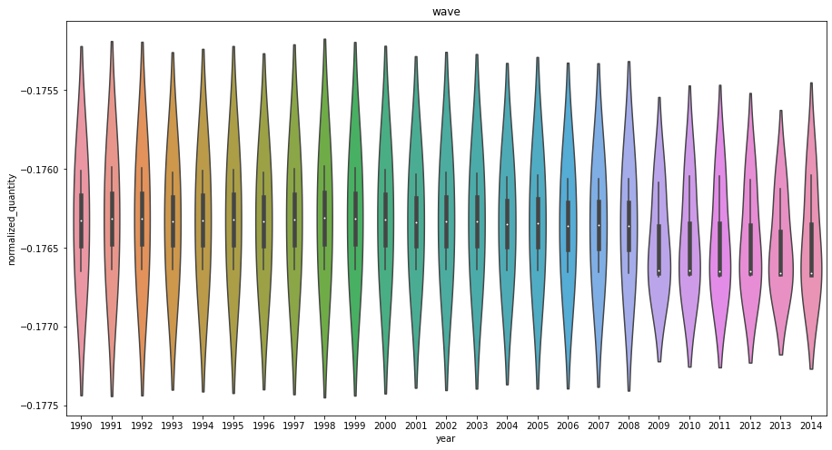

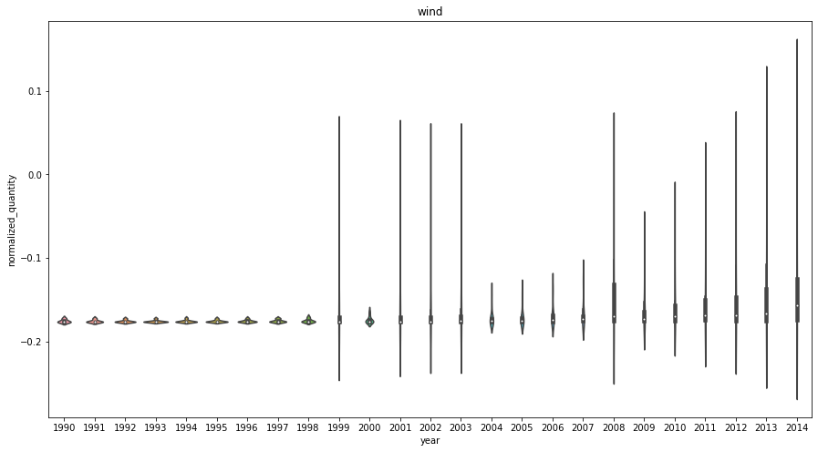

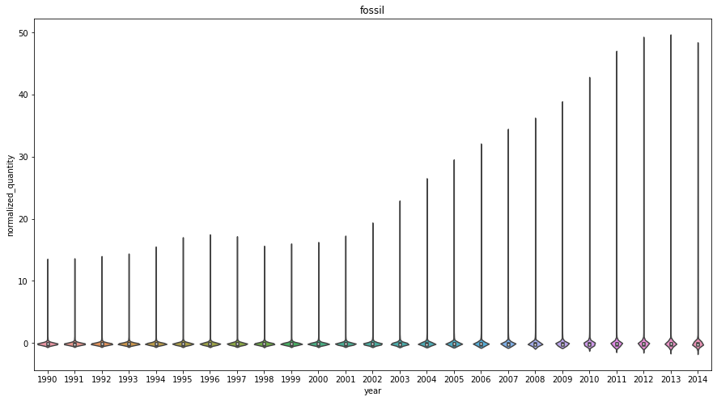

```python
for s in sources:
    # get dataframe where df5 has s in source column
    d=df5.loc[df5['source']==s]
    plt.subplots(figsize = (15,8))
    sns.violinplot(x=d["year"], y=d["normalized_quantity"]).set(title=s)
```

Of all the violin plots, only two seemed reasonably normally distributed: geo and wave. All the others were right-skewed(skewed upwards) in varying amounts of severity. This makes sense because the top producing countries have the resources to produce much more energy when that energy is easily extracted. Geo and wave are both too location specific. Two out of eight is not a good percentage so perhaps we can instead sum up all the production in one year.

### Regression

Now we will plot a regression line for all subplots to predict the trend in the future. Most of our original subplot do not form a linear relationship but perhaps summing the production of all countries each year will reveal a linear trend.

```python
# will hold a dictionary of regression equation coefficients
equations={}
```

```python
# returns year and total quantity of all countries for given year and source
def get_total_quantity(year,source):
    total = -1
    data = df5.loc[(df5['year'] == year) & (df5['source'] == source)]
    if len(data) > 0:
        if total == -1:
            total = 0
        for d in data.index:
            total += df5.loc[d, 'quantity']

    return year, total
```

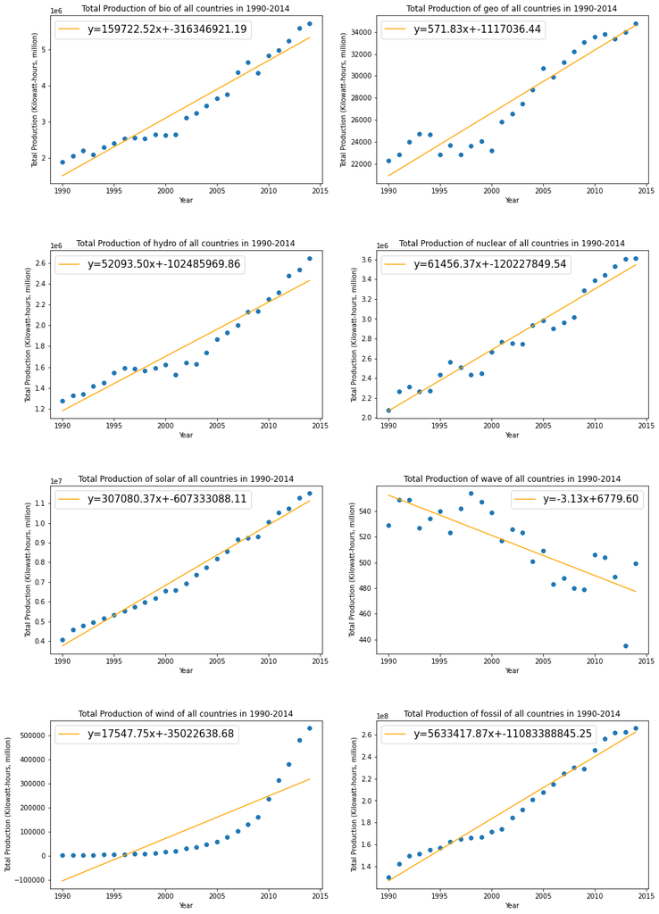

```python
num_rows = 4
num_cols = 2

fig, axes = plt.subplots(nrows=num_rows, ncols=num_cols)

i = 0
for r in range(0,num_rows):
    for c in range (0, num_cols):
        if i < 8:
            focus = sources[i]
            # plot line data for each source
            X=[]
            Y=[]
            for y in range(1990, 2015):
                tup = get_total_quantity(y, focus)
                # an element is only added to lists if that country listed that commodity that year
                if int(tup[1]) != -1:
                    X.append(tup[0])
                    Y.append(tup[1])
            # plot for each country
            axes[r,c].scatter(X, Y)

            m, b = np.polyfit(X, Y, 1)
            equations[focus]=(m,b)
            axes[r,c].plot(X, m*np.array(X) + b, color='orange',label='y={:.2f}x+{:.2f}'.format(m,b))

            axes[r,c].set_xlabel('Year')
            axes[r,c].set_ylabel('Total Production (Kilowatt-hours, million)')
            axes[r,c].set_title('Total Production of '+ str(focus) +' of all countries in 1990-2014')
            axes[r,c].legend(fontsize=15)
            i += 1

# adjust size and padding
fig.set_figwidth(num_cols*8)
fig.set_figheight(num_rows*6)

plt.subplots_adjust(wspace=0.2,
                    hspace=0.4)
```

Most of these plots present a strong linear trend with the exception of wind. To address that, we could try a polynomial regression. However, which degree should we use?

### Machine Learning

To tackle this problem, we can use supervised machine learning with holdout cross-validation to select the best degree. I set the training set to be 70% of the wind data and holdout set to other 30%. Then I iterate over a list of degrees ranging from 1 to 9. Any higher higher will be unnecessary for a convex scatterplot with no inflection. For each degree, I train features on the training set by tranforming existing features into a higher degree and fit them into sklearn's Linear Regression. Then I predict on that training set and evaluate how well my prediction performed under the holdout set by extracting the rMSE (square root of the mean squared error). The degree with the lowest rMSE is the best fitted one.

As degree increases, our model becomes more complex and training loss will always decrease. However, generalization loss only decreases up to a point and then start to increase because of overfitting. Not only that, complex models require extremely large coefficients on polynomials. Therefore we want the minimum degree that gives an acceptable performance.

```python
x=[get_total_quantity(i,'wind')[0] for i in range(1990,2015)]
y=[get_total_quantity(i,'wind')[1] for i in range(1990,2015)]
```

```
Best degree 9 with RMSE 13013.187786830471
```

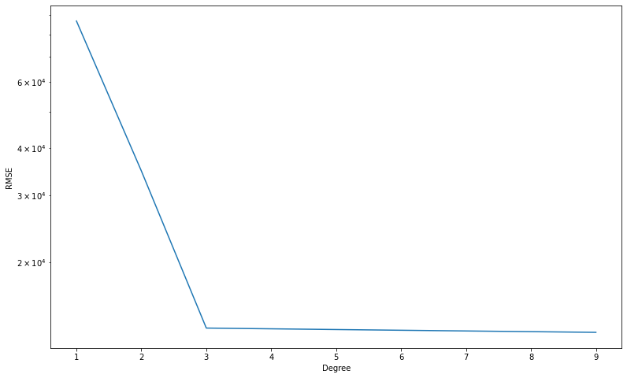

```python
from sklearn.linear_model import LinearRegression
from sklearn.preprocessing import PolynomialFeatures
from sklearn.metrics import mean_squared_error
from sklearn.model_selection import train_test_split

X = np.array(x).reshape(-1, 1)
y = y

x_train, x_test, y_train, y_test = train_test_split(X, y, test_size=0.3)

rmses = []
degrees = np.arange(1, 10)
min_rmse, min_deg = 1e10, 0

for deg in degrees:

    # Train features
    poly_features = PolynomialFeatures(degree=deg, include_bias=False)
    x_poly_train = poly_features.fit_transform(x_train)

    # Linear regression
    poly_reg = LinearRegression()
    poly_reg.fit(x_poly_train, y_train)

    # Compare with test data
    x_poly_test = poly_features.fit_transform(x_test)
    poly_predict = poly_reg.predict(x_poly_test)
    poly_mse = mean_squared_error(y_test, poly_predict)
    poly_rmse = np.sqrt(poly_mse)
    rmses.append(poly_rmse)

    # Cross-validation of degree
    if min_rmse > poly_rmse:
        min_rmse = poly_rmse
        min_deg = deg

# Plot and present results
print('Best degree {} with RMSE {}'.format(min_deg, min_rmse))

fig, ax = plt.subplots()
ax.plot(degrees, rmses)
ax.set_yscale('log')
ax.set_xlabel('Degree')
ax.set_ylabel('RMSE')
fig.set_figwidth(13)
fig.set_figheight(8)
```

From the plot showing the rMSE's of each degree, we can clearly see dramatic improvement from linear to quadratic and then to cubic regressions. However, any higher and we receive diminishing returns. 9 may have the lowerst rMSE(expected since it is the max degree we tested) but 3 seems the most practical. Therefore we choose cubic.

```python
# returns result of cubic polynomial with coefficients a, b, and c for input x
def objective(x, a, b, c, d):
    return (a * x) + (b * x**2) + (c * x**3) + d
```

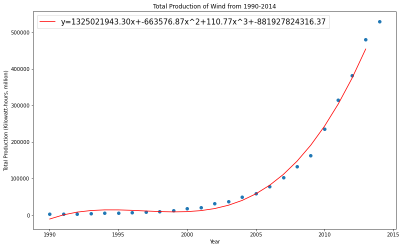

```python
from scipy.optimize import curve_fit
from matplotlib import pyplot
from numpy import arange
popt, _ = curve_fit(objective, x, y)

# get coefficients
a, b, c, d = popt
equations['wind']=(a,b,c,d)
# plot input vs output
fig, ax = plt.subplots()
ax.scatter(x, y)
# define a sequence of inputs between the smallest and largest known inputs
x_line = arange(min(x), max(x), 1)
# calculate the output for the range
y_line = objective(x_line, a, b, c, d)

# create a line plot for the mapping function
ax.plot(x_line, y_line, '-', color='red',label='y={:.2f}x+{:.2f}x^2+{:.2f}x^3+{:.2f}'.format(a,b,c,d))
ax.set_title('Total Production of Wind from 1990-2014')
ax.set_xlabel('Year')
ax.set_ylabel('Total Production (Kilowatt-hours, million)')
ax.legend(fontsize=15)
fig.set_figwidth(13)
fig.set_figheight(8)
```

Using scipy's curve_fit function, we found a cubic function that fits our wind data much more nicely than a linear one.

### Hypothesis testing

We have our regression equations and they seem to fit very nicely but to make sure of this, we need to do some hypothesis testing. When performing hypothesis testing on a regression line, our null hypothesis will always be all the slope parameters ($\beta _i$) are equal to 0. In other words, will the regression model contain at least one useful predictor? If our p-value is less than our significance level $\alpha$, we will reject the null hypothesis in favor of our alternate nypothesis, which is that the regression model does contain at least one useful predictor. That is what we want to achieve, because it says our model is useful on some level. Otherwise, we fail to reject our null hypothesis. We will be perform this hypothesis testing on each subplot.

$\alpha =0.05$

For wind:

$H_0:\beta _1=\beta _2=\beta _3=0$

$H_a:$ At least one $\beta _i\neq 0$ for $i=1,2,3$

The rest:

$H_0:\beta _1=0$

$H_a:\beta _1\neq 0$

Let's first start with the rest as their linear regressions make hypothesis testing much easier.

```python
# get sources without 'wind'
linear_reg = np.delete(sources, np.where(sources == 'wind'))
linear_reg
```

```
array(['bio', 'geo', 'hydro', 'nuclear', 'solar', 'wave', 'fossil'],
      dtype=object)
```

```python
from statsmodels.regression import linear_model
from statsmodels.api import add_constant

for focus in linear_reg:
    # response
    Y = [get_total_quantity(i,focus)[0] for i in range(1990,2015)]
    # predictor
    X = add_constant([get_total_quantity(i,focus)[1] for i in range(1990,2015)])

    # use sklearn to generate learn model
    model = linear_model.OLS(Y, X)
    results = model.fit()
    print(focus)
    print(results.pvalues)
    print(results.summary())
```

```
bio
[2.91467611e-60 2.94636001e-15]
                            OLS Regression Results
==============================================================================
Dep. Variable:                      y   R-squared:                       0.936
Model:                            OLS   Adj. R-squared:                  0.934
Method:                 Least Squares   F-statistic:                     338.6
Date:                Wed, 21 Jul 2021   Prob (F-statistic):           2.95e-15
Time:                        19:55:02   Log-Likelihood:                -50.425
No. Observations:                  25   AIC:                             104.8
Df Residuals:                      23   BIC:                             107.3
Df Model:                           1
Covariance Type:            nonrobust
==============================================================================
                 coef    std err          t      P>|t|      [0.025      0.975]
------------------------------------------------------------------------------
const       1981.9640      1.153   1719.044      0.000    1979.579    1984.349
x1          5.863e-06   3.19e-07     18.402      0.000     5.2e-06    6.52e-06
==============================================================================
Omnibus:                        2.346   Durbin-Watson:                   0.364
Prob(Omnibus):                  0.309   Jarque-Bera (JB):                1.179
Skew:                           0.058   Prob(JB):                        0.555
Kurtosis:                       1.943   Cond. No.                     1.10e+07
==============================================================================

Notes:
[1] Standard Errors assume that the covariance matrix of the errors is correctly specified.
[2] The condition number is large, 1.1e+07. This might indicate that there are
strong multicollinearity or other numerical problems.
geo
[4.15581560e-50 1.02323485e-12]
                            OLS Regression Results
==============================================================================
Dep. Variable:                      y   R-squared:                       0.894
Model:                            OLS   Adj. R-squared:                  0.890
Method:                 Least Squares   F-statistic:                     194.8
Date:                Wed, 21 Jul 2021   Prob (F-statistic):           1.02e-12
Time:                        19:55:02   Log-Likelihood:                -56.761
No. Observations:                  25   AIC:                             117.5
Df Residuals:                      23   BIC:                             120.0
```

[output cut: 148 more lines]

```
                 coef    std err          t      P>|t|      [0.025      0.975]
------------------------------------------------------------------------------
const       1968.5595      1.307   1506.690      0.000    1965.857    1971.262
x1          1.717e-07   6.56e-09     26.164      0.000    1.58e-07    1.85e-07
==============================================================================
Omnibus:                        1.726   Durbin-Watson:                   0.289
Prob(Omnibus):                  0.422   Jarque-Bera (JB):                1.050
Skew:                           0.121   Prob(JB):                        0.591
Kurtosis:                       2.025   Cond. No.                     9.59e+08
==============================================================================

Notes:
[1] Standard Errors assume that the covariance matrix of the errors is correctly specified.
[2] The condition number is large, 9.59e+08. This might indicate that there are
strong multicollinearity or other numerical problems.
```

For each energy source, we print the pvalues and the summary for our fitted linear model. All the p-values are less than 0.05, so we reject the null hypothesis and say we have sufficient evidence to conclude that the one slope parameter of each source is not 0, so a linear relationship exists for all of them.

OLS Regression Results

| Dep. Variable: | y | R-squared: | 0.951 |
| --- | --- | --- | --- |
| Model: | OLS | Adj. R-squared: | 0.946 |
| Method: | Least Squares | F-statistic: | 212.7 |
| Date: | Wed, 21 Jul 2021 | Prob (F-statistic): | 4.06e-15 |
| Time: | 19:55:06 | Log-Likelihood: | -296.40 |
| No. Observations: | 25 | AIC: | 598.8 |
| Df Residuals: | 22 | BIC: | 602.5 |
| Df Model: | 2 |  |  |
| Covariance Type: | nonrobust |  |  |

|  | coef | std err | t | P>\|t\| | [0.025 | 0.975] |
| --- | --- | --- | --- | --- | --- | --- |
| const | 5148.3279 | 470.033 | 10.953 | 0.000 | 4173.540 | 6123.116 |
| x1 | 3.436e+06 | 3.14e+05 | 10.953 | 0.000 | 2.79e+06 | 4.09e+06 |
| x2 | -3440.8902 | 313.351 | -10.981 | 0.000 | -4090.741 | -2791.040 |
| x3 | 0.8615 | 0.078 | 11.009 | 0.000 | 0.699 | 1.024 |

| Omnibus: | 2.636 | Durbin-Watson: | 0.228 |
| --- | --- | --- | --- |
| Prob(Omnibus): | 0.268 | Jarque-Bera (JB): | 1.377 |
| Skew: | -0.224 | Prob(JB): | 0.502 |
| Kurtosis: | 1.941 | Cond. No. | 2.21e+17 |

Notes:  
[1] Standard Errors assume that the covariance matrix of the errors is correctly specified.  
[2] The smallest eigenvalue is 3.31e-14. This might indicate that there are  
strong multicollinearity problems or that the design matrix is singular.

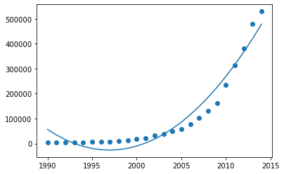

```python
from statsmodels.regression import linear_model
from statsmodels.api import add_constant
from sklearn.preprocessing import PolynomialFeatures
import statsmodels.api as sm

focus='wind'
x=np.array([get_total_quantity(i,focus)[0] for i in range(1990,2015)])
y=np.array([get_total_quantity(i,focus)[1] for i in range(1990,2015)])

# use sklearn to generate best cubic model
polynomial_features= PolynomialFeatures(degree=3)
xp = polynomial_features.fit_transform(x.reshape(-1,1))

model = sm.OLS(y, xp).fit()
ypred = model.predict(xp)
plt.scatter(x,y)
plt.plot(x,ypred)
model.summary()
```

For wind, we first have to tranform existing features into a cubic degree degree before we fit into our model. The p-values for all 3 of our coefficients are basically 0 so we reject the null hypothesis here too and say we have sufficient evidence to conclude that at least one of the slope parameters is not equal to 0.

The only issue here would be that the fitted cubic regression looks different from our polyfit cubic regression but this does not detract from the fact that a cubic regression is a useful predictor.

### Final Question

Now that we have analyzed the data sufficiently to get a good idea of what is going on and we have the our regression equations, we will address our beginning question: when will we stop stop relying fossil fuels as our primary source for energy?

To answer this, all we need to do is iterate over years until the sum of all predictions for non-fossil fuel outweigh the prediction for fossil fuels of a given year.

```python
for y in range(2114, 3114):
    total = 0
    for s in sources:
        if s=='wind':
            total+=objective(y, equations[s][0], equations[s][1], equations[s][2], equations[s][3])
        elif s=='fossil':
            total-=equations[s][0]*y+equations[s][1]
        else:
            total+=equations[s][0]*y+equations[s][1]
    if total>0:
        print('Year: '+str(y))
        print('Difference: '+str(total))
        break
```

```
Year: 2225
Difference: 10237062.196249485
```

### Conclusions

Although 2225 seems alarming, the specific year should not be taken too seriously. The most recent data was given is 2014 and we have certainly made a lot of progress since then. Additionally, the metric ton to kwh conversion with fossil fuels was heavily handwaved and many categories within might not have anything to do with producing energy. Finally, the further we predict into the future, the less accurate our models become. In the real world, we will stop producing energy from fossil fuels as by their nature as nonrenewable energy, we will run out at some point. However, these predictions still reveal how much we as a humanity rely on fossil fuels. If we want improvement in the near future, we must take drastic action immediately.

I hope that seeing the data science pipeline, from data extraction to wrangling data, data analysis, hypothesis testing, machine learning, and analysis, you gain a better understanding of how to leverage data to gain knowledge of the world around us.

### Extra Resources

To learn more about generating polynomial regressions with sklearn and optimizing degree, check out this blog [here](https://towardsdatascience.com/polynomial-regression-bbe8b9d97491).

To learn why we did the hypothesis testing the way we did, this [page](https://online.stat.psu.edu/stat501/lesson/6/6.4) explains F-statistics.

To learn more about the different sources of energy, check out [here](https://www.conserve-energy-future.com/different-energy-sources.php)

Check out the original dataset under Energy Statistics Database at http://data.un.org/Explorer.aspx